# Loan Data from Prosper

## Preliminary Wrangling

> This data set contains 113,937 loans with 81 variables on each loan, including loan amount, borrower rate (or interest rate), current loan status, borrower income, and many others.

Some questions to take into account:

- What factors affect a loan’s outcome status?
- What affects the borrower’s APR or interest rate?
- Are there differences between loans depending on how large the original loan amount was?

```python
# import all packages and set plots to be embedded inline
import numpy as np
import pandas as pd
import matplotlib.pyplot as plt
import seaborn as sb
import os
import datetime

%matplotlib inline
```

> Load in your dataset and describe its properties through the questions below. Try and motivate your exploration goals through this section.

```python
df = pd.read_csv('prosperLoanData.csv')
```

```python
df.info()
```

```
<class 'pandas.core.frame.DataFrame'>
RangeIndex: 113937 entries, 0 to 113936
Data columns (total 81 columns):
 #   Column                               Non-Null Count   Dtype
---  ------                               --------------   -----
 0   ListingKey                           113937 non-null  object
 1   ListingNumber                        113937 non-null  int64
 2   ListingCreationDate                  113937 non-null  object
 3   CreditGrade                          28953 non-null   object
 4   Term                                 113937 non-null  int64
 5   LoanStatus                           113937 non-null  object
 6   ClosedDate                           55089 non-null   object
 7   BorrowerAPR                          113912 non-null  float64
 8   BorrowerRate                         113937 non-null  float64
 9   LenderYield                          113937 non-null  float64
```

[output cut: 73 more lines]

**As the number of columns to work with is too large, we will trim down the variables to the ones found interesting for the analysis. These will be the following:**

| Variable | Description |
| --- | --- |
| ListingNumber | The number that uniquely identifies the listing to the public as displayed on the website. |
| LoanOriginationDate | The date the loan was originated. |
| Term | The length of the loan expressed in months. |
| BorrowerAPR | The Borrower's Annual Percentage Rate (APR) for the loan. |
| BorrowerRate | The Borrower's interest rate for this loan. |
| LenderYield | The Lender yield on the loan. Lender yield is equal to the interest rate on the loan less the servicing fee. |
| ProsperRating (Alpha) | The Prosper Rating assigned at the time the listing was created between AA - HR. Applicable for loans originated after July 2009. 0 - N/A, 1 - HR, 2 - E, 3 - D, 4 - C, 5 - B, 6 - A, 7 - AA. |
| ProsperScore | A custom risk score built using historical Prosper data. The score ranges from 1-10, with 10 being the best, or lowest risk score. Applicable for loans originated after July 2009. |
| ListingCategory | The category of the listing that the borrower selected when posting their listing: 0 - Not Available, 1 - Debt Consolidation, 2 - Home Improvement, 3 - Business, 4 - Personal Loan, 5 - Student Use, 6 … |
| Occupation | The Occupation selected by the Borrower at the time they created the listing. |
| EmploymentStatus | The employment status of the borrower at the time they posted the listing. |
| AvailableBankcardCredit | The total available credit via bank card at the time the credit profile was pulled. |
| DebtToIncomeRatio | The debt to income ratio of the borrower at the time the credit profile was pulled. This value is Null if the debt to income ratio is not available. This value is capped at 10.01 (any debt to income r… |
| IncomeRange | The income range of the borrower at the time the listing was created. |
| LoanOriginalAmount | The origination amount of the loan. |

```python
columns = ['ListingNumber','LoanOriginationDate','Term','BorrowerAPR','BorrowerRate','LenderYield','ProsperRating (Alpha)','ProsperScore','ListingCategory (numeric)',
           'Occupation','EmploymentStatus','AvailableBankcardCredit','DebtToIncomeRatio','IncomeRange','LoanOriginalAmount']
loans = df[columns]
loans.info()
```

```
<class 'pandas.core.frame.DataFrame'>
RangeIndex: 113937 entries, 0 to 113936
Data columns (total 15 columns):
 #   Column                     Non-Null Count   Dtype
---  ------                     --------------   -----
 0   ListingNumber              113937 non-null  int64
 1   LoanOriginationDate        113937 non-null  object
 2   Term                       113937 non-null  int64
 3   BorrowerAPR                113912 non-null  float64
 4   BorrowerRate               113937 non-null  float64
 5   LenderYield                113937 non-null  float64
 6   ProsperRating (Alpha)      84853 non-null   object
 7   ProsperScore               84853 non-null   float64
 8   ListingCategory (numeric)  113937 non-null  int64
 9   Occupation                 110349 non-null  object
 10  EmploymentStatus           111682 non-null  object
 11  AvailableBankcardCredit    106393 non-null  float64
 12  DebtToIncomeRatio          105383 non-null  float64
 13  IncomeRange                113937 non-null  object
 14  LoanOriginalAmount         113937 non-null  int64
dtypes: float64(6), int64(4), object(5)
memory usage: 13.0+ MB
```

```python
loans.rename(columns={'ProsperRating (Alpha)': 'ProsperRating',"ListingCategory (numeric)":"ListingCategory"},inplace = True)
```

```python
loans['LoanOriginationDate']= pd.to_datetime(loans['LoanOriginationDate'])
```

**As the information for ProsperRatings and ProsperScore is only available for post July 2009, we'll just consider post July 2009 loans for the study.**

**Analyzing notnull values for both periods we can see that previous to July 2009 there are only 9 values.**

```python
loans[loans.LoanOriginationDate.dt.date > datetime.date(2009, 7, 30)].ProsperRating.notnull().sum(),loans[loans.LoanOriginationDate.dt.date < datetime.date(2009, 7, 30)].ProsperRating.notnull().sum()
```

```
(84839, 9)
```

```python
loans = loans[loans.LoanOriginationDate.dt.date > datetime.date(2009, 7, 30)]
```

```python
loans[loans.ListingNumber.duplicated()]
```

|  | ListingNumber | LoanOriginationDate | Term | BorrowerAPR | BorrowerRate | LenderYield | ProsperRating | ProsperScore | ListingCategory | Occupation | EmploymentStatus | AvailableBankcardCredit | DebtToIncomeRatio | IncomeRange | LoanOriginalAmount |
| --- | --- | --- | --- | --- | --- | --- | --- | --- | --- | --- | --- | --- | --- | --- | --- |
| 9 | 1023355 | 2013-12-12 | 36 | 0.07620 | 0.0629 | 0.0529 | AA | 11.0 | 7 | Food Service | Employed | 77696.0 | 0.25 | $25,000-49,999 | 10000 |
| 999 | 1055932 | 2014-02-12 | 60 | 0.17710 | 0.1535 | 0.1435 | B | 7.0 | 1 | Other | Employed | 14190.0 | 0.35 | $25,000-49,999 | 10000 |
| 2539 | 1097584 | 2014-03-11 | 60 | 0.14528 | 0.1224 | 0.1124 | B | 10.0 | 1 | Police Officer/Correction Officer | Employed | 26503.0 | 0.18 | $100,000+ | 35000 |
| 4942 | 927246 | 2013-10-01 | 36 | 0.35356 | 0.3134 | 0.3034 | HR | 2.0 | 7 | Laborer | Employed | 798.0 | 0.07 | $50,000-74,999 | 4000 |
| 5812 | 920397 | 2013-11-14 | 36 | 0.24205 | 0.2045 | 0.1945 | C | 4.0 | 1 | NaN | Other | 1513.0 | 0.62 | $50,000-74,999 | 15000 |
| ... | ... | ... | ... | ... | ... | ... | ... | ... | ... | ... | ... | ... | ... | ... | ... |
| 113548 | 1158474 | 2014-03-04 | 60 | 0.22063 | 0.1960 | 0.1860 | D | 8.0 | 18 | Other | Employed | 105.0 | 0.15 | $75,000-99,999 | 14000 |
| 113636 | 904020 | 2013-11-12 | 36 | 0.21290 | 0.1760 | 0.1660 | C | 6.0 | 1 | NaN | Other | 3019.0 | 0.20 | $25,000-49,999 | 4000 |
| 113733 | 1002326 | 2013-11-13 | 60 | 0.20593 | 0.1819 | 0.1719 | B | 8.0 | 1 | Skilled Labor | Employed | 9185.0 | 0.42 | $50,000-74,999 | 10000 |
| 113773 | 1056749 | 2013-12-23 | 36 | 0.16324 | 0.1274 | 0.1174 | B | 6.0 | 1 | Other | Employed | 3529.0 | 0.36 | $25,000-49,999 | 10000 |
| 113863 | 928893 | 2013-11-22 | 36 | 0.12691 | 0.0990 | 0.0890 | A | 6.0 | 1 | Principal | Employed | 16835.0 | 0.18 | $25,000-49,999 | 6500 |

871 rows × 15 columns

```python
loans[loans.ListingNumber == 1158474]
```

|  | ListingNumber | LoanOriginationDate | Term | BorrowerAPR | BorrowerRate | LenderYield | ProsperRating | ProsperScore | ListingCategory | Occupation | EmploymentStatus | AvailableBankcardCredit | DebtToIncomeRatio | IncomeRange | LoanOriginalAmount |
| --- | --- | --- | --- | --- | --- | --- | --- | --- | --- | --- | --- | --- | --- | --- | --- |
| 92814 | 1158474 | 2014-03-04 | 60 | 0.22063 | 0.196 | 0.186 | D | 4.0 | 18 | Other | Employed | 105.0 | 0.15 | $75,000-99,999 | 14000 |
| 113548 | 1158474 | 2014-03-04 | 60 | 0.22063 | 0.196 | 0.186 | D | 8.0 | 18 | Other | Employed | 105.0 | 0.15 | $75,000-99,999 | 14000 |

```python
loans.drop_duplicates(subset=['ListingNumber'], keep='last', inplace=True)
```

```python
loans = loans[loans.ProsperRating.notnull()]
```

```python
# filling missing values for the Occupation as unknown and for the DebttoIncomeRatio as the mean
loans.Occupation = loans.Occupation.fillna('Unknown')
loans.DebtToIncomeRatio = loans.DebtToIncomeRatio.fillna(loans.DebtToIncomeRatio.mean())
```

```python
loans.info()
```

```
<class 'pandas.core.frame.DataFrame'>
Int64Index: 83968 entries, 1 to 113936
Data columns (total 15 columns):
 #   Column                   Non-Null Count  Dtype
---  ------                   --------------  -----
 0   ListingNumber            83968 non-null  int64
 1   LoanOriginationDate      83968 non-null  datetime64[ns]
 2   Term                     83968 non-null  int64
 3   BorrowerAPR              83968 non-null  float64
 4   BorrowerRate             83968 non-null  float64
 5   LenderYield              83968 non-null  float64
 6   ProsperRating            83968 non-null  object
 7   ProsperScore             83968 non-null  float64
 8   ListingCategory          83968 non-null  int64
 9   Occupation               83968 non-null  object
 10  EmploymentStatus         83968 non-null  object
 11  AvailableBankcardCredit  83968 non-null  float64
 12  DebtToIncomeRatio        83968 non-null  float64
 13  IncomeRange              83968 non-null  object
 14  LoanOriginalAmount       83968 non-null  int64
dtypes: datetime64[ns](1), float64(6), int64(4), object(4)
memory usage: 10.2+ MB
```

### What is the structure of your dataset?

> The dataset contains 83.968 unique loans with 15 related features.

### What is/are the main feature(s) of interest in your dataset?

> Identifying which of the features have an effect on the borrowersAPR (The term “annual percentage rate (APR)” refers to the annual rate of interest charged to borrowers and paid to investors). Also analyze the relationship between features such as the Ratings given to the borrower vs their social/economic status.

### What features in the dataset do you think will help support your investigation into your feature(s) of interest?

> - I expect that the LoanOriginalAmount will have a negative effect on the APR of the loan: the larger the total loan amount, the lower the APR.
> - I also think that the borrowers stated Income Range, loan term, Debt to Income and employment status will also have effects on the APR and the Rating associated with the borrower.
> - I think that Loan Amounts and their Listing Category vs IncomeRange / terms / Ratings will be related

## **Univariate Exploration**

```python
loans.IncomeRange.value_counts()
```

```
$50,000-74,999    25321
$25,000-49,999    23916
$100,000+         15055
$75,000-99,999    14362
$1-24,999          4620
Not employed        649
$0                   45
Name: IncomeRange, dtype: int64
```

```python
rate_order = ['HR','E','D','C','B','A','AA']
cat_var = pd.api.types.CategoricalDtype(ordered = True, categories = rate_order)
loans['ProsperRating'] = loans['ProsperRating'].astype(cat_var)

emp_order = ['Employed','Self-employed','Full-time','Part-time','Retired','Other','Not employed', 'Not available']
emp_var = pd.api.types.CategoricalDtype(ordered = True, categories = emp_order)
loans['EmploymentStatus'] = loans['EmploymentStatus'].astype(emp_var)

inc_order = [ 'Not employed','$0', '$1-24,999','$25,000-49,999','$50,000-74,999','$75,000-99,999','$100,000+',]
inc_var = pd.api.types.CategoricalDtype(ordered = True, categories = inc_order)
loans['IncomeRange'] = loans['IncomeRange'].astype(inc_var)
```

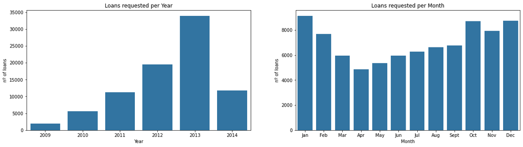

```python
base_color = sb.color_palette()[0]
plt.figure(figsize = [20, 5])

plt.subplot(1, 2, 1)
sb.countplot(x=loans.LoanOriginationDate.dt.year, data=loans, color=base_color)
plt.title('Loans requested per Year')
plt.xlabel('Year')
plt.ylabel('nº of loans')


plt.subplot(1, 2, 2)
sb.countplot(x=loans.LoanOriginationDate.dt.month, data=loans, color=base_color)
plt.title('Loans requested per Month')
plt.xlabel('Month')
plt.ylabel('nº of loans')
plt.xticks(np.arange(0,12,1),['Jan','Feb','Mar','Apr','May','Jun','Jul','Aug','Sept','Oct','Nov','Dec']);
```

> - 2013 was the year where more loans were requested. And normally the winter months have higher nº of loans than summer periods.

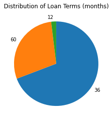

```python
sorted_counts = loans['Term'].value_counts()
plt.title('Distribution of Loan Terms (months)')
plt.pie(sorted_counts, labels=sorted_counts.index, startangle=90, counterclock=False);
```

> - Clearly, the most requested Loan Terms is 36 months.

```python
loans.describe()
```

|  | ListingNumber | Term | BorrowerAPR | BorrowerRate | LenderYield | ProsperScore | ListingCategory | AvailableBankcardCredit | DebtToIncomeRatio | LoanOriginalAmount |
| --- | --- | --- | --- | --- | --- | --- | --- | --- | --- | --- |
| count | 8.396800e+04 | 83968.000000 | 83968.000000 | 83968.000000 | 83968.000000 | 83968.000000 | 83968.000000 | 83968.000000 | 83968.000000 | 83968.000000 |
| mean | 7.712986e+05 | 42.463891 | 0.226948 | 0.196303 | 0.186298 | 5.954102 | 3.321587 | 11397.861697 | 0.258692 | 9062.272485 |
| std | 2.358852e+05 | 11.639703 | 0.080044 | 0.074746 | 0.074746 | 2.373331 | 4.369038 | 18628.126317 | 0.305703 | 6279.611231 |
| min | 4.162900e+05 | 12.000000 | 0.045830 | 0.040000 | 0.030000 | 1.000000 | 0.000000 | 0.000000 | 0.000000 | 1000.000000 |
| 25% | 5.571315e+05 | 36.000000 | 0.163610 | 0.135900 | 0.125900 | 4.000000 | 1.000000 | 1140.750000 | 0.160000 | 4000.000000 |
| 50% | 7.342810e+05 | 36.000000 | 0.219450 | 0.187500 | 0.177500 | 6.000000 | 1.000000 | 4568.000000 | 0.240000 | 7500.000000 |
| 75% | 9.756955e+05 | 60.000000 | 0.292540 | 0.257400 | 0.247400 | 8.000000 | 3.000000 | 13902.000000 | 0.310000 | 13500.000000 |
| max | 1.255725e+06 | 60.000000 | 0.423950 | 0.360000 | 0.340000 | 11.000000 | 20.000000 | 498374.000000 | 10.010000 | 35000.000000 |

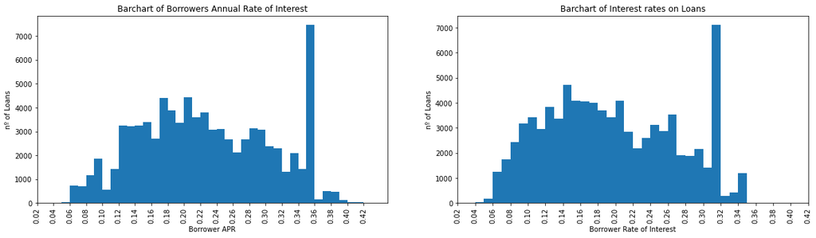

```python
plt.figure(figsize = [20, 5])

plt.subplot(1, 2, 1)
bins = np.arange(0.04, loans.BorrowerAPR.max()+0.01, 0.01)
plt.hist(data = loans, x = 'BorrowerAPR', bins = bins);
plt.xticks(np.arange(0.02,loans.BorrowerAPR.max()+0.01, 0.02), rotation=90)
plt.title('Barchart of Borrowers Annual Rate of Interest')
plt.ylabel('nº of Loans')
plt.xlabel('Borrower APR')

plt.subplot(1, 2, 2)
bins = np.arange(0.04, loans.BorrowerRate.max()+0.01, 0.01)
plt.hist(data = loans, x = 'BorrowerRate', bins = bins);
plt.xticks(np.arange(0.02,loans.BorrowerAPR.max()+0.01, 0.02), rotation=90)
plt.title('Barchart of Interest rates on Loans')
plt.ylabel('nº of Loans')
plt.xlabel('Borrower Rate of Interest');
```

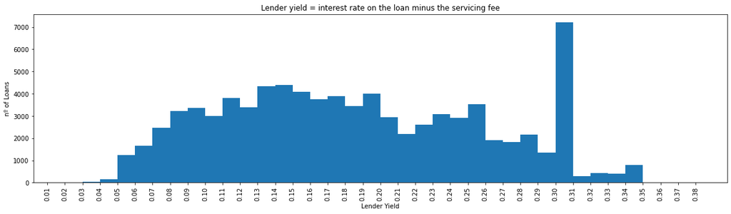

```python
base_color = sb.color_palette()[0]
plt.figure(figsize = [20, 5])

bins = np.arange(0.02, loans.LenderYield.max()+0.05, 0.01)
plt.hist(data = loans, x = 'LenderYield', bins = bins);
plt.xticks(np.arange(0.01,loans.LenderYield.max()+0.05, 0.01), rotation=90)
plt.title('Lender yield = interest rate on the loan minus the servicing fee')
plt.ylabel('nº of Loans')
plt.xlabel('Lender Yield');
```

> - We can observe that Lenders Yield and Borrowers APR (or rate) are directly related as the difference between them is the servicing fee applied to the Loan, charged by the Lender.

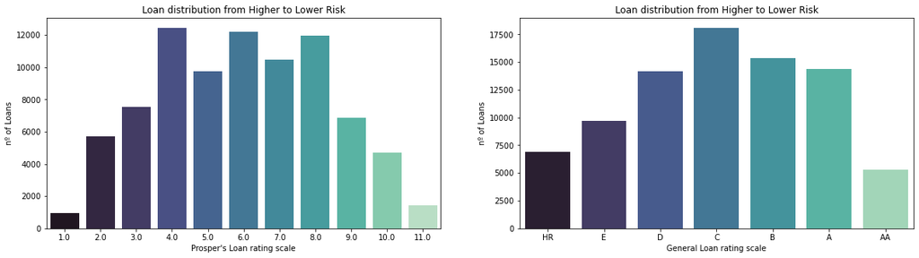

```python
plt.figure(figsize = [20, 5])

plt.subplot(1, 2, 1)
sb.countplot(data = loans, x = 'ProsperScore', palette='mako')
plt.title('Loan distribution from Higher to Lower Risk')
plt.ylabel('nº of Loans')
plt.xlabel('Prosper\'s Loan rating scale');

plt.subplot(1, 2, 2)
sb.countplot(data = loans, x = 'ProsperRating', palette='mako')
plt.title('Loan distribution from Higher to Lower Risk')
plt.ylabel('nº of Loans')
plt.xlabel('General Loan rating scale');
```

> - The Prosper score estimates the probability of a loan going “bad,” where “bad” is the probability of going 60+ days past due within the first twelve months from the date of loan origination.

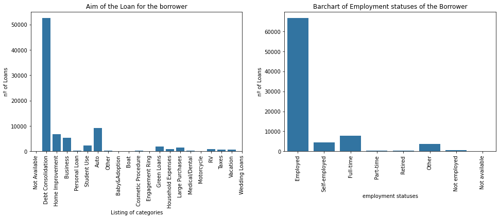

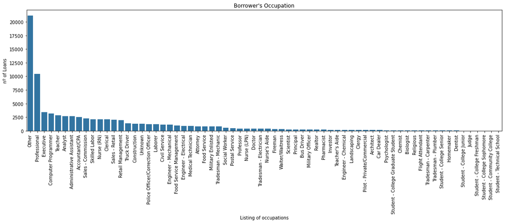

```python
plt.figure(figsize = [25, 5])
base_color = sb.color_palette()[0]

plt.subplot(1,3,1)
sb.countplot(data = loans, x = 'ListingCategory', color = base_color)
plt.xticks(np.arange(0,21,1),['Not Available','Debt Consolidation','Home Improvement','Business','Personal Loan','Student Use','Auto','Other','Baby&Adoption','Boat','Cosmetic Procedure','Engagement Ring','Green Loans','Household Expenses','Large Purchases','Medical/Dental', 'Motorcycle','RV','Taxes','Vacation',' Wedding Loans'],
          rotation=90)
plt.title('Aim of the Loan for the borrower')
plt.ylabel('nº of Loans')
plt.xlabel('Listing of categories');

plt.subplot(1,3,2)
sb.countplot(data = loans, x = 'EmploymentStatus', color = base_color)
plt.xticks(rotation=90)
plt.title('Barchart of Employment statuses of the Borrower')
plt.ylabel('nº of Loans')
plt.xlabel('employment statuses');

plt.figure(figsize = [65, 5])
plt.subplot(1,3,3)
sb.countplot(data = loans, x = 'Occupation', color = base_color, order = loans.Occupation.value_counts().index)
plt.xticks(rotation=90);
plt.title('Borrower\'s Occupation')
plt.ylabel('nº of Loans')
plt.xlabel('Listing of occupations');
```

> - ListingCategory shows thath the majority of the Loans are for debt consolidation. We can also see that the Loans are mainly requested by Employed people and the distribution of occupation of the sample. We can observe that students, Dentists and Judges are the groups that least Loans request (the first because they may already have a student dent with the university and the latters because they may earn enough money to not depend on Loans).

```python
loans.describe()
```

|  | ListingNumber | Term | BorrowerAPR | BorrowerRate | LenderYield | ProsperScore | ListingCategory | AvailableBankcardCredit | DebtToIncomeRatio | LoanOriginalAmount |
| --- | --- | --- | --- | --- | --- | --- | --- | --- | --- | --- |
| count | 8.396800e+04 | 83968.000000 | 83968.000000 | 83968.000000 | 83968.000000 | 83968.000000 | 83968.000000 | 83968.000000 | 83968.000000 | 83968.000000 |
| mean | 7.712986e+05 | 42.463891 | 0.226948 | 0.196303 | 0.186298 | 5.954102 | 3.321587 | 11397.861697 | 0.258692 | 9062.272485 |
| std | 2.358852e+05 | 11.639703 | 0.080044 | 0.074746 | 0.074746 | 2.373331 | 4.369038 | 18628.126317 | 0.305703 | 6279.611231 |
| min | 4.162900e+05 | 12.000000 | 0.045830 | 0.040000 | 0.030000 | 1.000000 | 0.000000 | 0.000000 | 0.000000 | 1000.000000 |
| 25% | 5.571315e+05 | 36.000000 | 0.163610 | 0.135900 | 0.125900 | 4.000000 | 1.000000 | 1140.750000 | 0.160000 | 4000.000000 |
| 50% | 7.342810e+05 | 36.000000 | 0.219450 | 0.187500 | 0.177500 | 6.000000 | 1.000000 | 4568.000000 | 0.240000 | 7500.000000 |
| 75% | 9.756955e+05 | 60.000000 | 0.292540 | 0.257400 | 0.247400 | 8.000000 | 3.000000 | 13902.000000 | 0.310000 | 13500.000000 |
| max | 1.255725e+06 | 60.000000 | 0.423950 | 0.360000 | 0.340000 | 11.000000 | 20.000000 | 498374.000000 | 10.010000 | 35000.000000 |

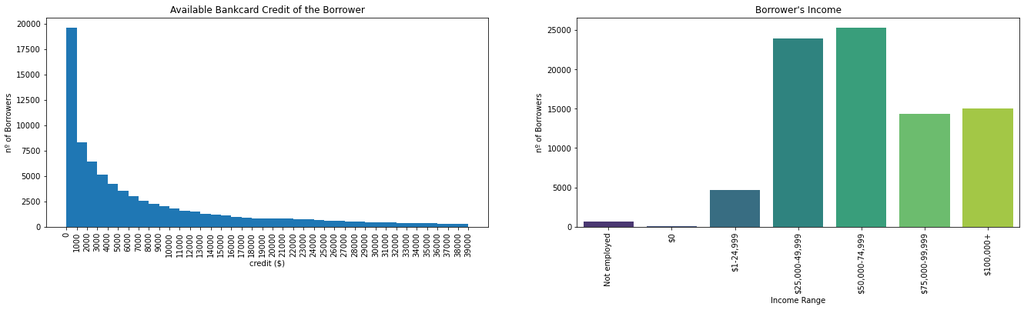

```python
plt.figure(figsize = [35, 5])
base_color = sb.color_palette()[0]

plt.subplot(1,3,2)
bins = np.arange(0, 40000, 1000)
plt.hist(data = loans, x = 'AvailableBankcardCredit', color=base_color, bins=bins)
plt.xticks(np.arange(0, 40000, 1000), rotation=90)
plt.title('Available Bankcard Credit of the Borrower')
plt.ylabel('nº of Borrowers')
plt.xlabel('credit ($)');

plt.subplot(1,3,3)
sb.countplot(data = loans, x = 'IncomeRange', palette='viridis')
plt.xticks(rotation=90);
plt.title('Borrower\'s Income')
plt.ylabel('nº of Borrowers')
plt.xlabel('Income Range');
```

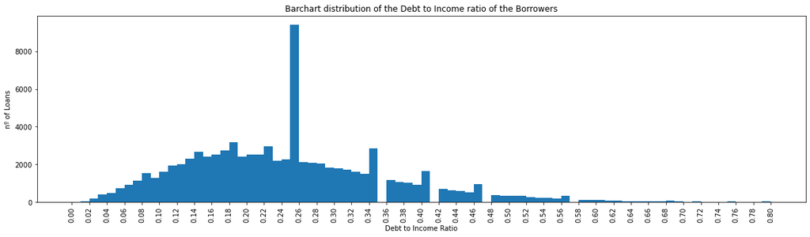

```python
# distribution of DebtToIncomeRatio
plt.figure(figsize = [20, 5])
bins = np.arange(0,0.81, 0.01)
plt.hist(data = loans, x = 'DebtToIncomeRatio', bins = bins)
plt.xticks(np.arange(0, 0.81, 0.02), rotation=90)
plt.xlabel('Debt to Income Ratio')
plt.ylabel('nº of Loans')
plt.title('Barchart distribution of the Debt to Income ratio of the Borrowers');
```

> - Distribution has unimodal shape peaking aroung 0.18 with a large peak around 0.25. This indicates most people have 1:4 ratio of debt to Income which would be a correct proportion.

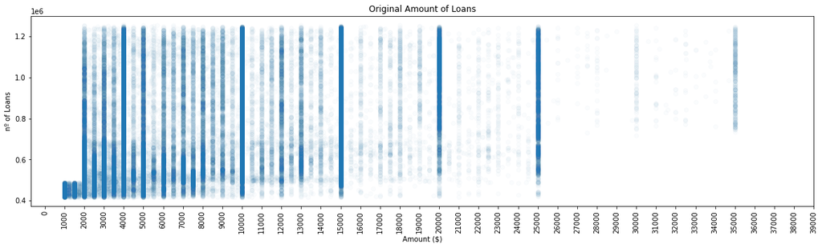

```python
# distribution of LoanOriginalAmount
plt.figure(figsize = [20, 5])
# bins = np.arange(0, 45000, 2500)
sb.regplot(data = loans, x = 'LoanOriginalAmount', y ='ListingNumber', scatter_kws={'alpha':1/50}, x_jitter=0.9, fit_reg=False)
plt.xticks(np.arange(0, 40000, 1000), rotation=90)
plt.xlabel('Amount ($)')
plt.ylabel('nº of Loans')
plt.title('Original Amount of Loans');
```

> - With this plot we can see that the most frequent Loan Amounts requested are at 4k, 5k, 10k, 15k, 20k, 25k.

### Discuss the distribution(s) of your variable(s) of interest. Were there any unusual points? Did you need to perform any transformations?

> - The main transformations were performed on the categorical features and some cleaning operations to drop duplicates and discard data previous to july 2009 due to missing information.
> - The distribution of the borrowers APR is spiked on 0.36 which is the typical rate applied to small dollar lending Loans [https://qcashfinancial.com/36-percent-apr-for-small-dollar-loans/]
> - The majority of loan Terms are 36 months, the year with higher Loan requests was 2013, the risk scale distribution for the Loans of this analysis follows a Normal distribution with C-rated Loans as the mean.
> - The great majority of borrowers are employed and have a debt to income ratio of 1:4.

### Of the features you investigated, were there any unusual distributions? Did you perform any operations on the data to tidy, adjust, or change the form of the data? If so, why did you do this?

> DebtToIncomeRatio is right skewed and Loan ratings and Income Ranges are a bit left skewed. There is no need to perform any transformations.

## **Bivariate Exploration**

```python
loans.head()
```

|  | ListingNumber | LoanOriginationDate | Term | BorrowerAPR | BorrowerRate | LenderYield | ProsperRating | ProsperScore | ListingCategory | Occupation | EmploymentStatus | AvailableBankcardCredit | DebtToIncomeRatio | IncomeRange | LoanOriginalAmount |
| --- | --- | --- | --- | --- | --- | --- | --- | --- | --- | --- | --- | --- | --- | --- | --- |
| 1 | 1209647 | 2014-03-03 | 36 | 0.12016 | 0.0920 | 0.0820 | A | 7.0 | 2 | Professional | Employed | 10266.0 | 0.18 | $50,000-74,999 | 10000 |
| 3 | 658116 | 2012-11-01 | 36 | 0.12528 | 0.0974 | 0.0874 | A | 9.0 | 16 | Skilled Labor | Employed | 30754.0 | 0.15 | $25,000-49,999 | 10000 |
| 4 | 909464 | 2013-09-20 | 36 | 0.24614 | 0.2085 | 0.1985 | D | 4.0 | 2 | Executive | Employed | 695.0 | 0.26 | $100,000+ | 15000 |
| 5 | 1074836 | 2013-12-24 | 60 | 0.15425 | 0.1314 | 0.1214 | B | 10.0 | 1 | Professional | Employed | 86509.0 | 0.36 | $100,000+ | 15000 |
| 6 | 750899 | 2013-04-18 | 36 | 0.31032 | 0.2712 | 0.2612 | E | 2.0 | 1 | Sales - Retail | Employed | 1929.0 | 0.27 | $25,000-49,999 | 3000 |

```python
num_vars = ['LoanOriginalAmount', 'BorrowerAPR','DebtToIncomeRatio']
cat_vars = ['Term','ProsperRating', 'EmploymentStatus','Occupation', 'IncomeRange', 'ListingCategory']
```

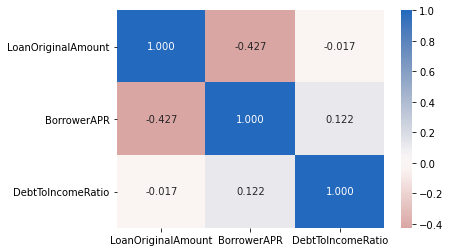

```python
sb.heatmap(loans[num_vars].corr(), annot = True, fmt = '.3f', cmap = 'vlag_r', center = 0);
```

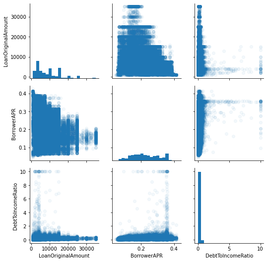

```python
g = sb.PairGrid(data = loans, vars = num_vars)
g = g.map_diag(plt.hist, bins=20)
g.map_offdiag(plt.scatter, alpha=0.05);
```

The correlation coefficient of Borrower's APR vs Loan original amount is -0.427, this negative correlation is also shown on the scatterplot. The initial hypothesis of, the greater the Loan Amount requested the lower the interest rate (APR) charged to the borrower.

Now we'll study the correlation of the numeric variables vs the categorical features.

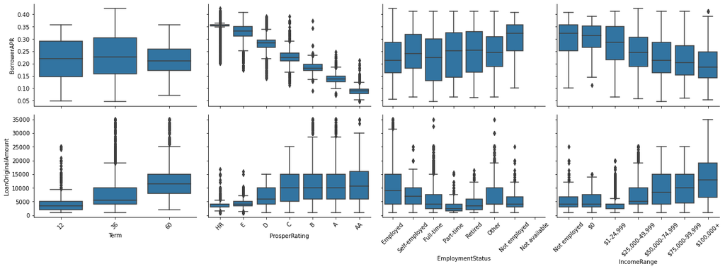

```python
def boxgrid(x, y, **kwargs):
    """ Quick hack for creating box plots with seaborn's PairGrid. """
    default_color = sb.color_palette()[0]
    sb.boxplot(x, y, color = default_color)

plt.figure(figsize = [10, 10])
g = sb.PairGrid(data = loans, y_vars= ['BorrowerAPR', 'LoanOriginalAmount'], x_vars = ['Term','ProsperRating', 'EmploymentStatus', 'IncomeRange'],
                height= 3, aspect = 1.5)
for axis in g.axes.flatten():
    axis.set_xticklabels(axis.get_xticklabels(), rotation=45)

g.map(boxgrid)
plt.show();
```

Now, looking into the relationships between the categorical variables:

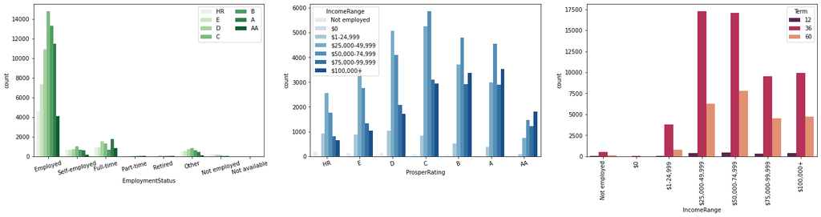

```python
plt.figure(figsize = [25, 5])

# BorrowerAPR vs term
ax=plt.subplot(1, 3, 1)
sb.countplot(data = loans, x = 'EmploymentStatus', hue = 'ProsperRating', palette = 'Greens')
plt.xticks(rotation=15)
ax.legend(loc = 1, ncol = 2); # re-arrange legend to remove overlapping;

# BorrowerAPR vs. ProsperRating
ax = plt.subplot(1, 3, 2)
sb.countplot(data = loans, x = 'ProsperRating', hue = 'IncomeRange', palette = 'Blues')
plt.xticks(rotation = 15);


# BorrowerAPR vs. IncomeRange
ax = plt.subplot(1, 3, 3)
sb.countplot(data = loans, x = 'IncomeRange', hue = 'Term', palette = 'rocket')
plt.xticks(rotation=90);
```

> - From our first plot we can observe that the great majority of Loans belong to "employed" category with quite a normal distribution. When looking into the "Full-time" employment status we can also read that the distribution has a higher proportion of better-ranked Loans.
> - Interestingly we can see that as the Prosper Rate improves (HR -> AA) the distribution of the income Range changes from skewed to the right to skewed to the left. This means that on better rated Loans, there is a major proportion of borrowers with high incomes.
> - Although the 36-month Term Loans are the most requested for every income range, we can see that the 60-month term seems to follow a normal distribution with mean on the 50-75k income range.

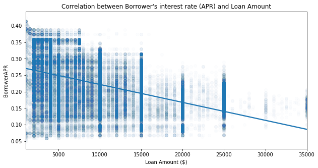

```python
plt.figure(figsize = [10, 5])
base_color = sb.color_palette()[0]
sb.regplot(data = loans, x = 'LoanOriginalAmount', y = 'BorrowerAPR', scatter_kws={'alpha':0.01}, x_jitter=0.3)
plt.title('Correlation between Borrower\'s interest rate (APR) and Loan Amount')
plt.xlabel('Loan Amount ($)');
```

[figure not shown]

```python
plt.figure(figsize = [8, 6])
sb.regplot(data = loans, x = 'BorrowerAPR', y = 'DebtToIncomeRatio', scatter_kws={'alpha':1/50})
plt.ylim([0, 1.25])
plt.xlabel('DebtToIncomeRatio')
plt.title('Correlation between Borrower\'s interest rate (APR) and its Debt to Income Ratio')
plt.ylabel('BorrowerAPR')
plt.show()
```

> - From the previous plots we can see the already commented negative correlation between the Borrowers interest rate and the amount of the Loan requested. As the amount is higher, the interests decrease.
> - From the second plot we can observe a small but positive relationship between the Borrower's APR and their Debt to Income Ratio. This means that the higher the proportion of debt to the borrower's income, the higher the interests charged, because it is a higher risk transaction for Prosper.

### Relationships you observed in this part of the investigation. How did the feature(s) of interest vary with other features in the dataset?

> - The borrower APR is negatively associated with the loan original amount, which means that the higher the loan amount, the lower the APR.
> - The Prosper Rating also has a strong effect on the borrower APR, which decreases with the better rating as shown in the boxplots.

## **Multivariate Exploration**

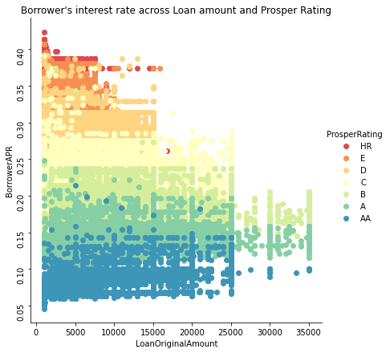

```python
g = sb.FacetGrid(data = loans, hue = 'ProsperRating', height=6, palette='Spectral');
g.map(plt.scatter, 'LoanOriginalAmount','BorrowerAPR' );
plt.title('Borrower\'s interest rate across Loan amount and Prosper Rating');
plt.ylabel('BorrowerAPR');
plt.yticks(rotation=90);
g.add_legend();
plt.show();
```

> - Following with the analysis of the Borrower's APR vs the Loan Amount where we found a negative correlation, adding in the Prosper Rating confirms that this is a powerful combination given that the higher the rating the lower the interest and each of the categories is clearly plotted.

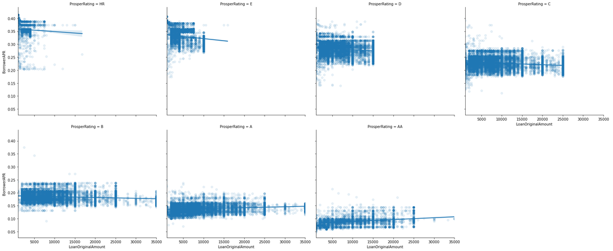

```python
g=sb.FacetGrid(data=loans, aspect=1.2, height=5, col='ProsperRating', col_wrap=4)
g.map(sb.regplot, 'LoanOriginalAmount', 'BorrowerAPR', x_jitter=0.04, scatter_kws={'alpha':0.1});
g.add_legend();
```

> - We can see that the relationship BorrowerAPR vs Loan Amount goes from negative on ratings HR- B to slighly positive on ratings A and AA.

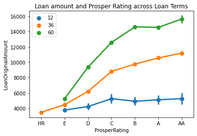

```python
sb.pointplot(data=loans,x='ProsperRating',y='LoanOriginalAmount', hue='Term' );
plt.title( 'Loan amount and Prosper Rating across Loan Terms');
# plt.ylabel('BorrowerAPR')
# plt.yticks(rotation=90)
plt.legend()
```

> - As stated in the bivariate analysis, we saw that higher loans equaled higher Terms. Now, it can also be confirmed that this pattern is extensible to all the Prosper Ratings.

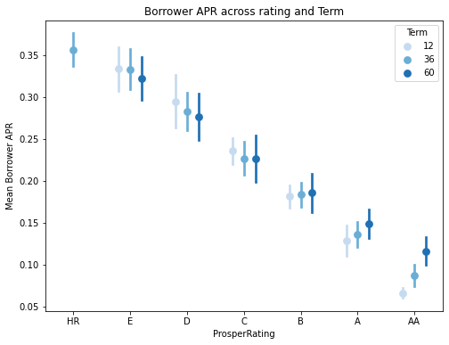

```python
fig = plt.figure(figsize = [8,6])
ax = sb.pointplot(data = loans, x = 'ProsperRating', y = 'BorrowerAPR', hue = 'Term',
           palette = 'Blues', linestyles = '', dodge = 0.4, ci='sd')
plt.title('Borrower APR across rating and Term')
plt.ylabel('Mean Borrower APR')
ax.set_yticklabels([],minor = True);
```

> - Related with the first multivariate plot, we can see that the better the rating the less interest rate. And adding in the Loan Terms we can see that as the Loan Rating gets better, the pattern is that the Terms increase. This is probably be due to the increase of the Loan Amount.

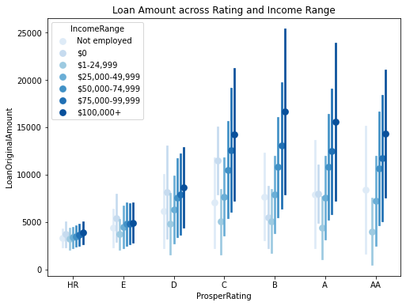

```python
fig = plt.figure(figsize = [8,6])
ax = sb.pointplot(data = loans, x = 'ProsperRating', y = 'LoanOriginalAmount', hue = 'IncomeRange',
           palette = 'Blues', linestyles = '', dodge = 0.4, ci='sd')
plt.title('Loan Amount across Rating and Income Range')
# plt.ylabel('Mean Borrower APR')
ax.set_yticklabels([],minor = True);
```

> - Comparing the same variables as previously but adding the income range to the plot, we can see that per each Rating the Loan amount requested is proportional to the income range of the borrower (higher income range, higher loan amount requested).

### Talk about some of the relationships you observed in this part of the investigation. Were there features that strengthened each other in terms of looking at your feature(s) of interest?

> - Extended the borrower APR vs loan amount by adding in the Prosper rating. The multivariate exploration showed that the relationship between borrower APR and loan amount goes from negative on ratings HR-B to slighly positive relationship on ratings A and AA.
> - We can also see that the better the Prosper Rating the less Interest Rate is charged. And adding the Loan Terms, we can see that as the Loan Rating gets better, the pattern is that the Terms increase. This is probably also due to the increase of the Loan Amount.

### Were there any interesting or surprising interactions between features?

```python
loans.to_csv('LoanData_cleaned.csv')
```